# presentation

Jakob Alderson & Tal bracha

2022-07-27

# Introduction

Most suicide attacks do not occur as a single and unrelated case, they usually occur as part of a period of suicide attacks or several at the same time. The strategic logic of the suicide attacks works mainly against liberal democratic countries, influencing public opinion and exerting pressure on the government. In this work, we will examine if indicators of human capital can affect the lethality of terrorist attacks.

# Our research question and hypothesis

Is there a connection between human capital and the lethality of suicidal attacks?

According to the literature we expect to see that indices like sex, age, and socioeconomic status will affect the lethality of suicidal attacks.

we expect that there is a strong relationship between older age and a higher unemployment rate to the lethality of suicide attacks. In particular women will be more lethal than men.

In addition, we expect to see a rise in the popularity of female suicide attacks, and we expect women to use more concealed weapons than men like belt bombs.

# Our database

In our project we used “The Database on Suicide Attacks (DSAT)” from the University of Chicago it contains specific information for all suicide attacks committed in modern history, from 1982 to 2019. Event records in the DSAT are highly detailed and coded for over 60 variables (not including source information).

The variables are divided into five broad categories:

1. Basic information, including attack location, date, and casualty counts.
2. Target information, including target type category (security / political / civilian) and their relation to state or international infrastructure.
3. Attacker biographical information, including attacker name, age, gender, nationality, and religious affiliation.
4. Claim information, including a list of groups that explicitly claim or deny credit for an attack, as well as groups suspected of involvement.
5. Sources, including texts of news articles and wire service alerts used in coding the attack.

# Literature 1 - Human Capital and the Productivity of Suicide Bombers

Benmelech’s and Berrebi’s article (2017) provides the first detailed empirical analysis of the relationship between suicide bomber’s characteristics and their performance in a suicide bombing attacks, The conclusion was that Palestinian terror organizations match older and more-educated suicide bombers to more important Israeli targets, another conclusion was that older and more-educated suicide bombers kill more people in their suicide attacks when assigned to important targets. Furthermore, older and more-educated suicide bombers are less likely to fail or to be caught when they attack.

This paper also contributes to the debate on the relation between education, poverty, and terrorism. While suicide bombers are on average more educated than the general Palestinian population, their estimate of a higher education among suicide bombers is three times lower than the figures reported by Berrebi (2003) and Krueger and Maleckova (2003).

# Literature 2 - What’s Special about Female Suicide Terrorism?

O’Rourke’s article (2009) analyzes the interaction between the motivations of individual attackers and terrorist group strategies. To do so it combines a quantitative analysis of all known suicide terrorist attacks between 1981 and July 2008 with a strategic account of why terrorist organizations employ female suicide terrorism and case studies of individual female attackers. The author advances five main claims:

1)She reveals the superior effectiveness of female suicide terrorism from the perspective of the groups that employ women.

2)She explains that terrorist groups increasingly enlist women as suicide attackers because of their higher effectiveness.

3)She demonstrates that terrorist groups adapt their discourse, catering to the specific individual motives of potential female suicide attackers to recruit them.

4)She shows that female attackers are driven by the same general motives and circumstances that drive men.

5)She concludes that, unless target states adapt their defensive strategies, we should expect an increase in female suicide terrorism.

# Literature 3 - Economic Conditions and the Quality of Suicide Terrorism

In this article Benmelech et al.(2010) analyze the link between economic conditions and the lethality of suicide terrorism. literature up to that point showed that poverty and economic conditions didn’t affect the quantity of terror. Focusing on Palestinian suicide terrorists against Israeli targets between the years 2000 and 2006 they wanted to check the correlation between economic conditions the characteristics of suicide terrorists and the targets they attack. They concluded that poor economic conditions and high unemployment enable terror organizations to recruit more educated, mature and experienced suicide terrorists who attack more important targets.

# Literature 4 - Wolves in Sheep’s Clothing: Assessing the Effect of Gender Norms on the Lethality of Female Suicide Terrorism

In this research Thomas(2021) shows that the gender of the attackers and the gender norms in the country they made the attack influence the lethality of the attack using data on individual suicide attacks from 1985 to 2015. She concluded that women are more lethal than men when it comes to suicide attacks but only in countries with restrictive gender norms and practices because in those countries women are seen as peaceful in character and apolitical therefore they don’t seem like a threat to the people. And in countries where women are seen as equal to men they didn’t have an edge when it comes to the lethality of the attack.

Moreover, Terrorists have also exploited the association between motherhood and innocence by deploying expectant mothers or women pretending to be pregnant in suicide attacks, by being pregnant or faking to be pregnant women can conceal their weapons (like vests and belts) more effectively also some scholars suggest that pregnancy may further discourage frisks, providing female terrorists greater cover.

# Interactive map of suicide attacks between 1982 and 2019

[interactive chart not shown]

# Data Cleaning of attacks:

```
## # A tibble: 6 × 94
##   data_release    event_id summary        status ct_sources event_date date_year
##   <chr>              <int> <chr>          <chr>       <int> <chr>          <int>
## 1 02-Oct-20    -2146485992 6/23/2015: In… Confi…          2 6/23/2015       2015
## 2 02-Oct-20    -2146060571 1/14/2017: In… Possi…          3 1/14/2017       2017
## 3 02-Oct-20    -2145067987 10/15/2004: I… Confi…          4 10/15/2004      2004
## 4 02-Oct-20    -2145029986 7/20/2017: In… Possi…          5 7/20/2017       2017
## 5 02-Oct-20    -2143985988 10/3/2012: In… Confi…          4 10/3/2012       2012
## 6 02-Oct-20    -2143771747 10/23/2010: I… Confi…          3 10/23/2010      2010
## # … with 87 more variables: date_month <int>, date_day <int>,
## #   wounded_low <int>, wounded_high <int>, killed_low <int>, killed_high <int>,
## #   killed_low_civilian <int>, killed_high_civilian <int>,
## #   killed_low_political <int>, killed_high_political <int>,
## #   killed_low_security <int>, killed_high_security <int>, ct_belt_bomb <int>,
## #   ct_truck_bomb <int>, ct_car_bomb <int>, ct_weapon_oth <int>,
## #   ct_weapon_unk <int>, weapon_id <int>, weapon_txt <chr>, …
```

After some data cleaning:

```
## # A tibble: 6 × 5
##      event_id casualties country     date_year weapon_txt
##         <int>      <dbl> <chr>           <int> <chr>
## 1 -2146485992         13 Syria            2015 Car bomb
## 2 -2146060571         40 Syria            2017 Unspecified
## 3 -2145067987         19 Iraq             2004 Car bomb
## 4 -2145029986          2 Afghanistan      2017 Truck bomb
## 5 -2143985988        146 Syria            2012 Car bomb
## 6 -2143771747          8 Russia           2010 Car bomb
```

# Data Cleaning of attackers:

```
##   data_release    event_id attacker_id  gender birth_year age_time_death
## 1    02-Oct-20 -2146485992  -274979578 Unknown         -1             -1
## 2    02-Oct-20 -2146060571 -1349440448 Unknown         -1             -1
## 3    02-Oct-20 -2146060571  1487611308 Unknown         -1             -1
## 4    02-Oct-20 -2145067987   663458966 Unknown         -1             -1
## 5    02-Oct-20 -2145029986  -163911859 Unknown         -1             -1
## 6    02-Oct-20 -2143985988  1406415357 Unknown         -1             -1
##   birth_admin0_id birth_admin0_cow_id birth_admin1_id birth_city_id
## 1             301                   0            5656    1523635399
## 2             301                   0            5656    1523635399
## 3             301                   0            5656    1523635399
## 4             301                   0            5656    1523635399
## 5             301                   0            5656    1523635399
## 6             301                   0            5656    1523635399
##   birth_admin0_txt  birth_admin1_txt birth_city_txt
## 1          Unknown Unknown (Unknown)        Unknown
## 2          Unknown Unknown (Unknown)        Unknown
## 3          Unknown Unknown (Unknown)        Unknown
## 4          Unknown Unknown (Unknown)        Unknown
## 5          Unknown Unknown (Unknown)        Unknown
## 6          Unknown Unknown (Unknown)        Unknown
```

after some data cleaning:

```
## # A tibble: 6 × 5
##      event_id attacker_id age_time_death gender birth_city
##         <int>       <int>          <int> <chr>  <chr>
## 1 -2134654500  1845652330             26 Male   Palestine
## 2 -2123020174  -135992336             20 Male   Palestine
## 3 -2121629020   309934450             21 Male   Palestine
## 4 -2116822737   124071698             23 Male   Syria
## 5 -2105951685  1695931383             23 Male   Pakistan
## 6 -2101445564  1033915410             23 Male   Palestine
```

# Normality visualtization:

[figure not shown]

The data is in Poisson distribution, we have a massive positive right skew.

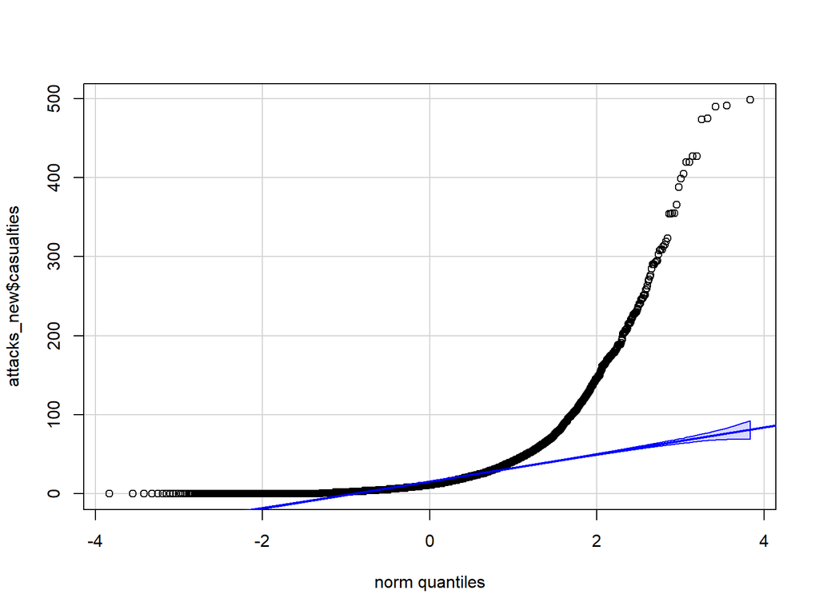

# Square root data transformation - Log(10) data transformation - Inverse data transformation:

[figure not shown]

# log 10 and log looks like normal distribution, but what’s the problem?

```
##
##  D'Agostino skewness test
##
## data:  log10(attacks_new$casualties + 1)
## skew = -0.1088, z = -3.9484, p-value = 7.866e-05
## alternative hypothesis: data have a skewness
```

```
##
##  D'Agostino skewness test
##
## data:  log(attacks_new$casualties + 1)
## skew = -0.1088, z = -3.9484, p-value = 7.866e-05
## alternative hypothesis: data have a skewness
```

too many repetitions!

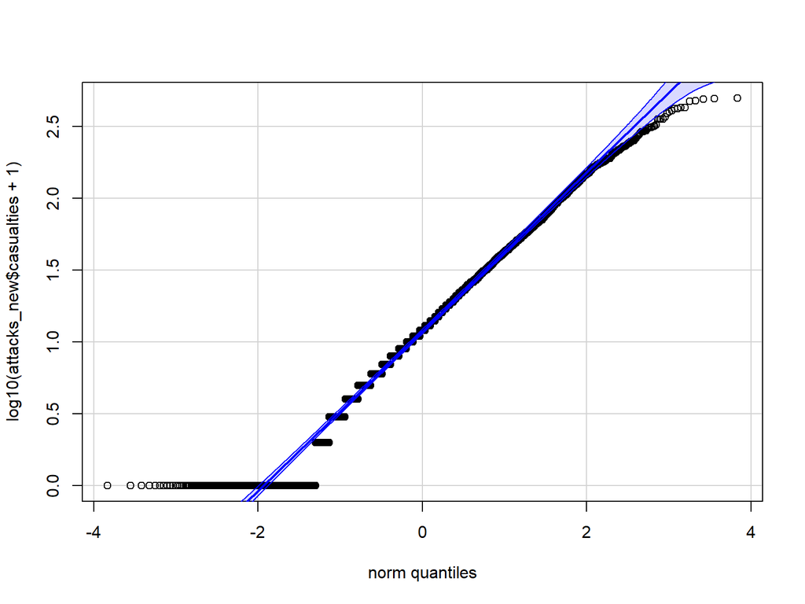

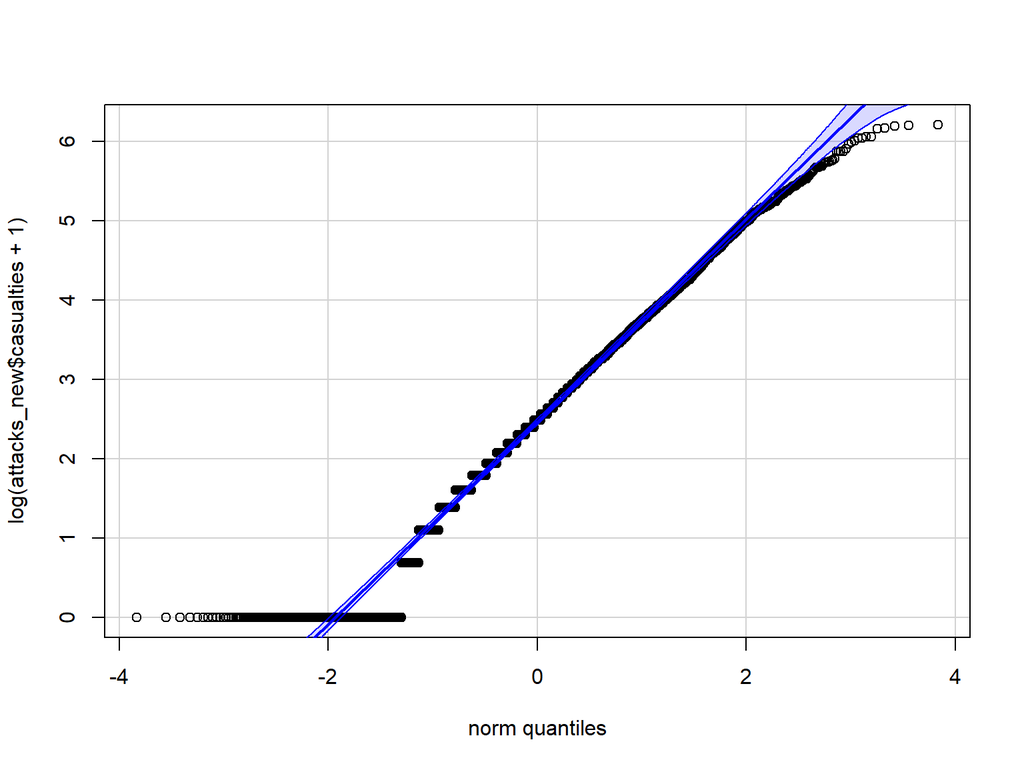

# Poisson vs quasi-Poisson vs negative binomial distribution

Our data has a Poisson distribution. The problem with Poisson distribution is that it is rather inflexible in the fact that it assumes that mean is equal to variance, if this assumption is not met, our distrebution might be quasi-Poisson, or negative binomial distribution

```
## [1] 24.25851
```

```
## [1] 1625.712
```

```
## [1] 17.4095
```

```
## [1] 379.039
```

```
## [1] 137.9321
```

```
## [1] 749.7151
```

```
## [1] 237.1207
```

```
## [1] 799.3711
```

```
## [1] 338
```

```
## [1] 974.4286
```

```
## [1] 452.8
```

```
## [1] 1298.622
```

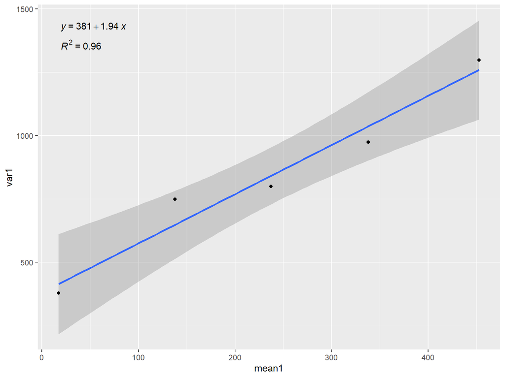

# Poisson vs quasi-Poisson vs negative binomial distribution P2

The variance of a quasi-Poisson model is a linear function of the mean while the variance of a negative binomial model is a quadratic function of the mean. These variance relationships affect the weights in the iteratively weighted least-squares algorithm of fitting models to data.

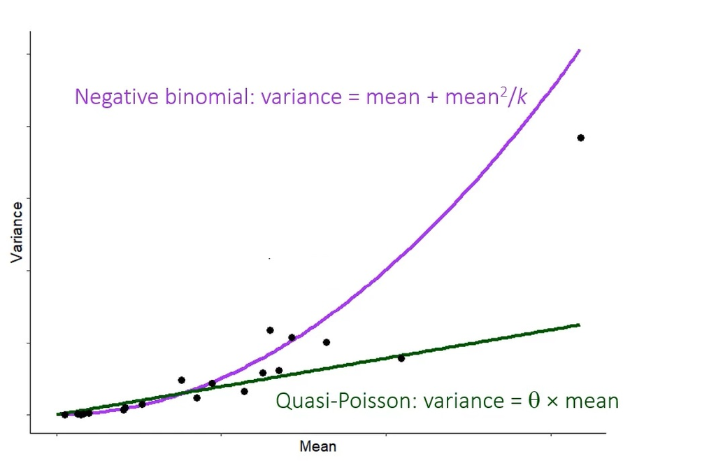

quasi-Poisson vs negative binomial distribution

# Male vs female count graph

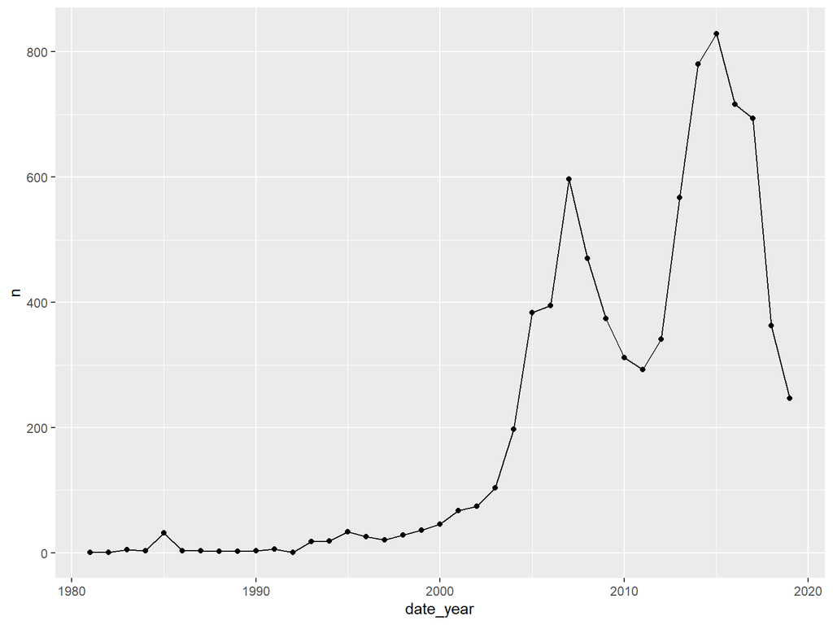

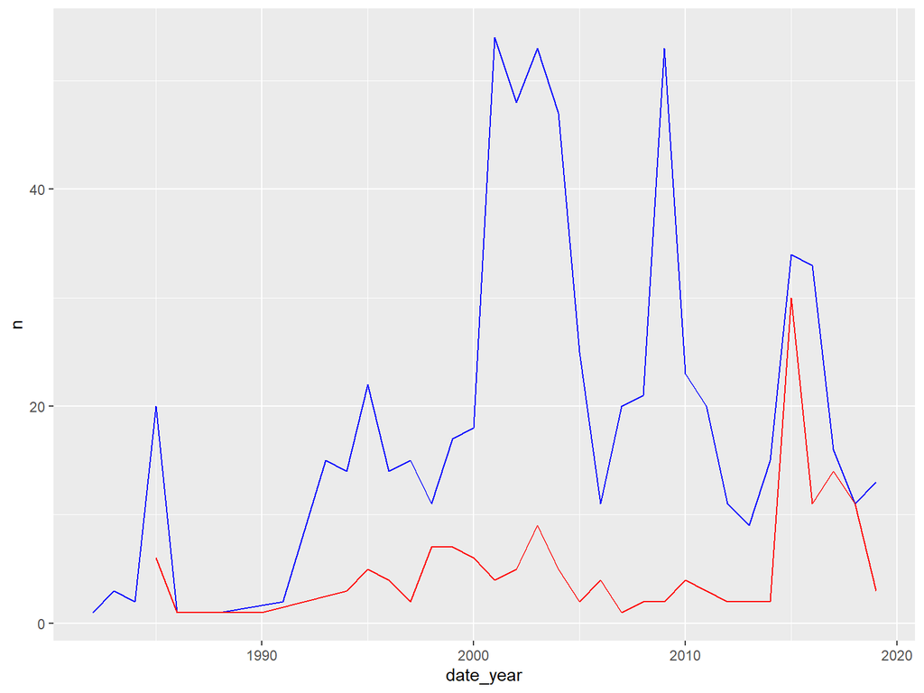

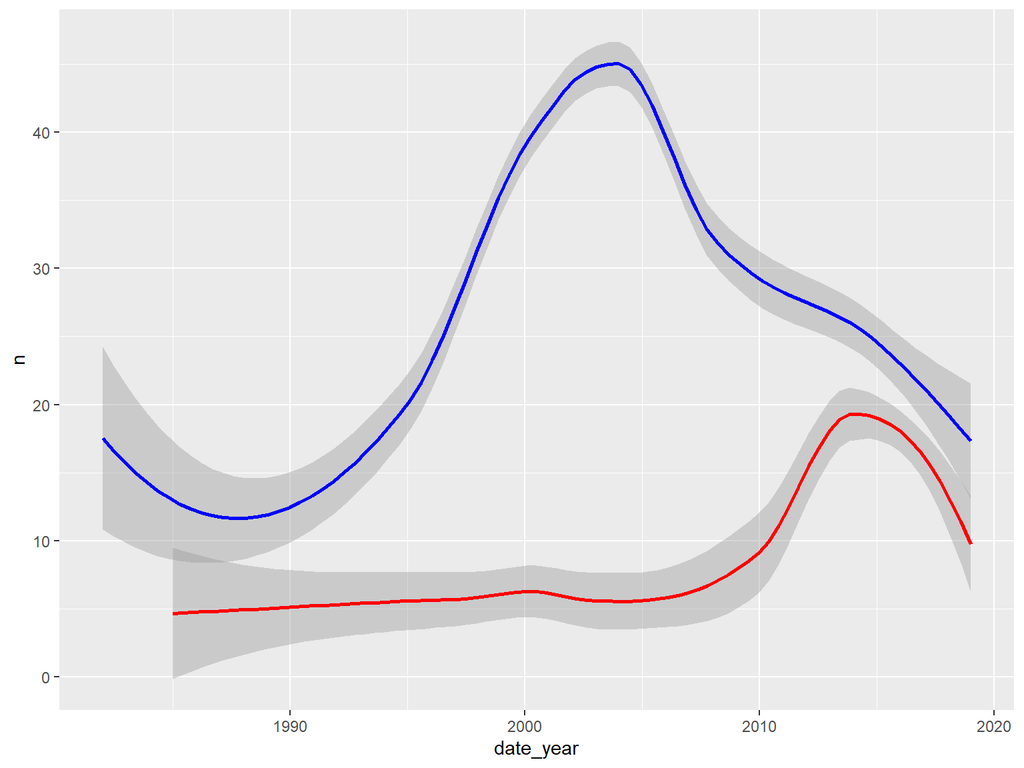

# male vs female weapons

```
## # A tibble: 17 × 3
##    weapon_txt            n precentage
##    <chr>             <int>      <dbl>
##  1 Airplane             10     0.124
##  2 Animal bomb           3     0.0371
##  3 Backpack bomb        38     0.469
##  4 Belt bomb          2657    32.8
##  5 Boat bomb           103     1.27
##  6 Car bomb           3549    43.8
##  7 Cart bomb            11     0.136
##  8 Mixed                43     0.531
##  9 Motorcycle bomb     361     4.46
## 10 Non-suicide IED       2     0.0247
## 11 Other PBIED         152     1.88
## 12 Other VBIED          29     0.358
## 13 Scuba bomb           19     0.235
## 14 Truck bomb          487     6.02
## 15 Turban bomb           3     0.0371
## 16 Unspecified         380     4.69
## 17 Unspecified PBIED   247     3.05
```

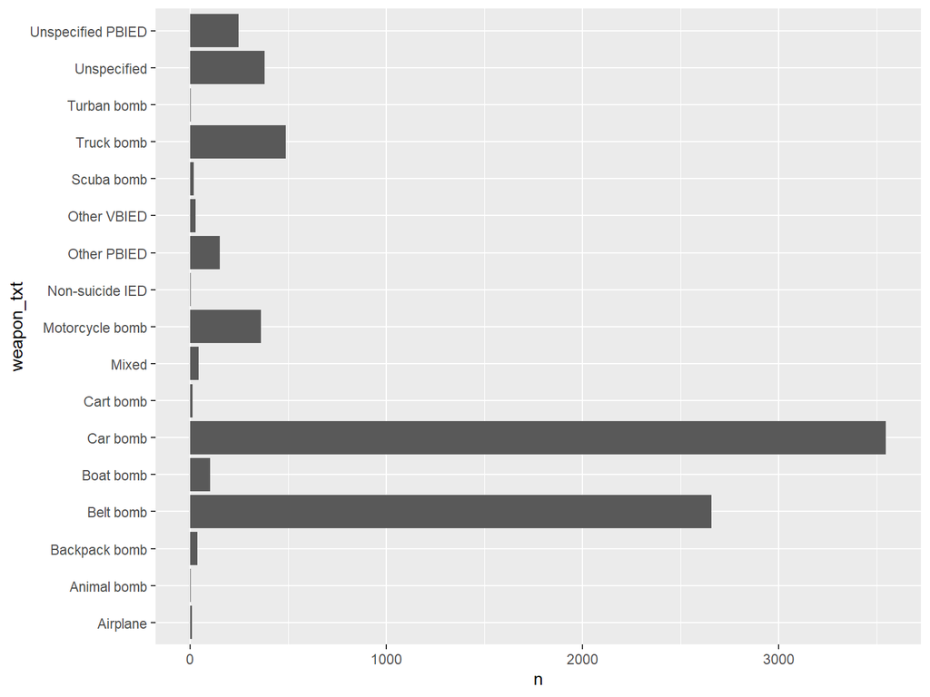

```
## [1] 674
```

```
## [1] 155
```

```
## # A tibble: 13 × 3
##    weapon_txt        n_male n_female
##    <chr>              <int>    <int>
##  1 Airplane               9       NA
##  2 Animal bomb            2       NA
##  3 Backpack bomb         17        4
##  4 Belt bomb            314       84
##  5 Boat bomb             60       18
##  6 Car bomb             151       10
##  7 Cart bomb              2       NA
##  8 Motorcycle bomb       19        1
##  9 Other PBIED           29        6
## 10 Scuba bomb            13        4
## 11 Truck bomb            34        4
## 12 Unspecified           13       11
## 13 Unspecified PBIED     11       13
```

```
##
##  2-sample test for equality of proportions with continuity correction
##
## data:  c(84, 314) out of c(155, 674)
## X-squared = 2.624, df = 1, p-value = 0.1053
## alternative hypothesis: two.sided
## 95 percent confidence interval:
##  -0.01491646  0.16703669
## sample estimates:
##    prop 1    prop 2
## 0.5419355 0.4658754
```

```
##
##  2-sample test for equality of proportions with continuity correction
##
## data:  c(4, 17) out of c(155, 674)
## X-squared = 1.5104e-30, df = 1, p-value = 1
## alternative hypothesis: two.sided
## 95 percent confidence interval:
##  -0.0276261  0.0287939
## sample estimates:
##     prop 1     prop 2
## 0.02580645 0.02522255
```

```
##
##  2-sample test for equality of proportions with continuity correction
##
## data:  c(18, 60) out of c(155, 674)
## X-squared = 0.7917, df = 1, p-value = 0.3736
## alternative hypothesis: two.sided
## 95 percent confidence interval:
##  -0.03168704  0.08590357
## sample estimates:
##     prop 1     prop 2
## 0.11612903 0.08902077
```

```
##
##  2-sample test for equality of proportions with continuity correction
##
## data:  c(10, 151) out of c(155, 674)
## X-squared = 19.485, df = 1, p-value = 1.014e-05
## alternative hypothesis: two.sided
## 95 percent confidence interval:
##  -0.213353 -0.105686
## sample estimates:
##     prop 1     prop 2
## 0.06451613 0.22403561
```

# comparisson_world

```
##
##  Wilcoxon rank sum test with continuity correction
##
## data:  both_gender1$casualties by both_gender1$gender
## W = 50002, p-value = 0.4058
## alternative hypothesis: true location shift is not equal to 0
```

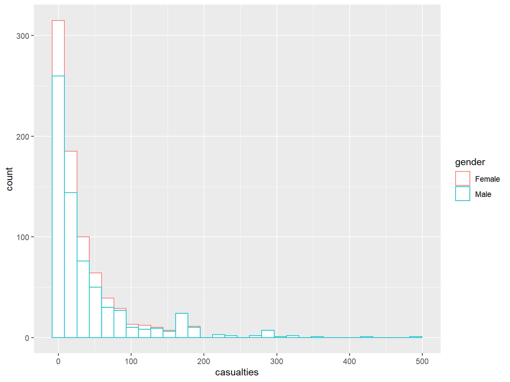

# comparisson_sri_lanka

```
##
##  Wilcoxon rank sum test with continuity correction
##
## data:  both_gender2$casualties by both_gender2$gender
## W = 1631, p-value = 0.9263
## alternative hypothesis: true location shift is not equal to 0
```

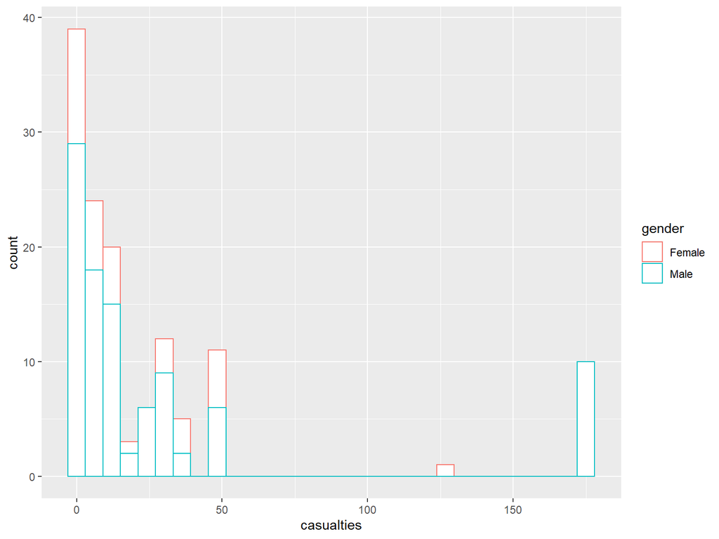

# comparisson_Russia

```
##
##  Wilcoxon rank sum test with continuity correction
##
## data:  both_gender3$casualties by both_gender3$gender
## W = 313.5, p-value = 0.1984
## alternative hypothesis: true location shift is not equal to 0
```

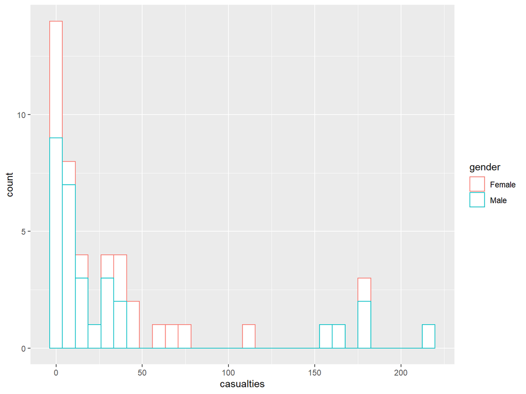

# sri_ lanka _ male

```
##
## Call:
## glm(formula = casualties ~ age_time_death + Education_Index +
##     GDP + Unemployment_Male, family = "quasipoisson", data = attacks_sri_lanka_man)
##
## Deviance Residuals:
##     Min       1Q   Median       3Q      Max
## -11.843   -4.576   -1.420    3.039   11.081
##
## Coefficients:
##                     Estimate Std. Error t value Pr(>|t|)
## (Intercept)        48.480663  79.368408   0.611    0.543
## age_time_death      0.079972   0.267285   0.299    0.765
## Education_Index   -55.600029 127.059622  -0.438    0.663
## GDP                -0.006491   0.029225  -0.222    0.825
## Unemployment_Male  -0.846789   2.079134  -0.407    0.685
##
## (Dispersion parameter for quasipoisson family taken to be 740.5753)
##
##     Null deviance: 5647.6  on 95  degrees of freedom
## Residual deviance: 2704.4  on 91  degrees of freedom
## AIC: NA
##
## Number of Fisher Scoring iterations: 6
```

```
##
##  Kendall's rank correlation tau
##
## data:  attacks_sri_lanka_man$casualties and attacks_sri_lanka_man$age_time_death
## z = 0.01931, p-value = 0.9846
## alternative hypothesis: true tau is not equal to 0
## sample estimates:
##         tau
## 0.001458496
```

```
##
##  Kendall's rank correlation tau
##
## data:  attacks_sri_lanka_man$casualties and attacks_sri_lanka_man$Education_Index
## z = -2.7113, p-value = 0.006701
## alternative hypothesis: true tau is not equal to 0
## sample estimates:
##        tau
## -0.2042454
```

```
##
##  Kendall's rank correlation tau
##
## data:  attacks_sri_lanka_man$casualties and attacks_sri_lanka_man$GDP
## z = -2.1274, p-value = 0.03339
## alternative hypothesis: true tau is not equal to 0
## sample estimates:
##        tau
## -0.1602541
```

```
##
##  Kendall's rank correlation tau
##
## data:  attacks_sri_lanka_man$casualties and attacks_sri_lanka_man$Unemployment_Male
## z = 3.2981, p-value = 0.0009733
## alternative hypothesis: true tau is not equal to 0
## sample estimates:
##       tau
## 0.2499604
```

# sri_ lanka _ female

```
##
## Call:
## glm(formula = casualties ~ age_time_death + Education_Index +
##     GDP + Unemployment_Female, family = "quasipoisson", data = attacks_sri_lanka_female)
##
## Deviance Residuals:
##    Min      1Q  Median      3Q     Max
## -7.346  -5.396  -1.447   2.928  12.513
##
## Coefficients:
##                       Estimate Std. Error t value Pr(>|t|)
## (Intercept)          39.371981  26.511928   1.485    0.148
## age_time_death        0.108917   0.069435   1.569    0.128
## Education_Index     -54.651437  38.604949  -1.416    0.168
## GDP                   0.001429   0.002260   0.632    0.532
## Unemployment_Female  -0.287112   0.225948  -1.271    0.214
##
## (Dispersion parameter for quasipoisson family taken to be 28.26651)
##
##     Null deviance: 918.92  on 33  degrees of freedom
## Residual deviance: 809.05  on 29  degrees of freedom
## AIC: NA
##
## Number of Fisher Scoring iterations: 6
```

```
##
##  Kendall's rank correlation tau
##
## data:  attacks_sri_lanka_female$casualties and attacks_sri_lanka_female$age_time_death
## z = 0.2892, p-value = 0.7724
## alternative hypothesis: true tau is not equal to 0
## sample estimates:
##        tau
## 0.03781186
```

```
##
##  Kendall's rank correlation tau
##
## data:  attacks_sri_lanka_female$casualties and attacks_sri_lanka_female$Education_Index
## z = -0.37907, p-value = 0.7046
## alternative hypothesis: true tau is not equal to 0
## sample estimates:
##         tau
## -0.04930976
```

```
##
##  Kendall's rank correlation tau
##
## data:  attacks_sri_lanka_female$casualties and attacks_sri_lanka_female$GDP
## z = 0.34875, p-value = 0.7273
## alternative hypothesis: true tau is not equal to 0
## sample estimates:
##        tau
## 0.04536498
```

```
##
##  Kendall's rank correlation tau
##
## data:  attacks_sri_lanka_female$casualties and attacks_sri_lanka_female$Unemployment_Female
## z = 1.0159, p-value = 0.3097
## alternative hypothesis: true tau is not equal to 0
## sample estimates:
##       tau
## 0.1321502
```

# russia_man

```
##
## Call:
## glm(formula = casualties ~ age_time_death + Education_Index +
##     GDP + Unemployment_Male, family = "quasipoisson", data = attacks_russia_male)
##
## Deviance Residuals:
##      Min        1Q    Median        3Q       Max
## -11.5948   -5.9324   -3.7189    0.0283   19.3108
##
## Coefficients:
##                     Estimate Std. Error t value Pr(>|t|)
## (Intercept)        8.291e+01  4.319e+01   1.920   0.0680 .
## age_time_death    -1.382e-02  3.596e-02  -0.384   0.7045
## Education_Index   -9.089e+01  5.370e+01  -1.692   0.1047
## GDP                5.616e-05  1.483e-04   0.379   0.7085
## Unemployment_Male -1.204e+00  5.014e-01  -2.401   0.0252 *
## ---
## Signif. codes:  0 '***' 0.001 '**' 0.01 '*' 0.05 '.' 0.1 ' ' 1
##
## (Dispersion parameter for quasipoisson family taken to be 97.06004)
##
##     Null deviance: 2126.9  on 26  degrees of freedom
## Residual deviance: 1481.5  on 22  degrees of freedom
## AIC: NA
##
## Number of Fisher Scoring iterations: 6
```

```
##
##  Kendall's rank correlation tau
##
## data:  attacks_russia_male$casualties and attacks_russia_male$age_time_death
## z = -0.58991, p-value = 0.5553
## alternative hypothesis: true tau is not equal to 0
## sample estimates:
##         tau
## -0.08421824
```

```
##
##  Kendall's rank correlation tau
##
## data:  attacks_russia_male$casualties and attacks_russia_male$Education_Index
## z = -0.30499, p-value = 0.7604
## alternative hypothesis: true tau is not equal to 0
## sample estimates:
##         tau
## -0.04517422
```

```
##
##  Kendall's rank correlation tau
##
## data:  attacks_russia_male$casualties and attacks_russia_male$GDP
## z = -0.21785, p-value = 0.8275
## alternative hypothesis: true tau is not equal to 0
## sample estimates:
##        tau
## -0.0322673
```

```
##
##  Kendall's rank correlation tau
##
## data:  attacks_russia_male$casualties and attacks_russia_male$Unemployment_Male
## z = -1.3292, p-value = 0.1838
## alternative hypothesis: true tau is not equal to 0
## sample estimates:
##        tau
## -0.1971768
```

# russia_female

```
##
## Call:
## glm(formula = casualties ~ age_time_death + Education_Index +
##     GDP + Unemployment_Female, family = "quasipoisson", data = attacks_russia_female)
##
## Deviance Residuals:
##    Min      1Q  Median      3Q     Max
## -9.256  -3.837  -1.447   2.585   9.034
##
## Coefficients:
##                       Estimate Std. Error t value Pr(>|t|)
## (Intercept)          4.600e+01  4.092e+01   1.124   0.2849
## age_time_death      -2.115e-02  5.122e-02  -0.413   0.6876
## Education_Index     -3.528e+01  5.227e+01  -0.675   0.5136
## GDP                 -2.482e-04  1.688e-04  -1.471   0.1693
## Unemployment_Female -1.805e+00  7.491e-01  -2.410   0.0346 *
## ---
## Signif. codes:  0 '***' 0.001 '**' 0.01 '*' 0.05 '.' 0.1 ' ' 1
##
## (Dispersion parameter for quasipoisson family taken to be 37.45835)
##
##     Null deviance: 716.49  on 15  degrees of freedom
## Residual deviance: 428.07  on 11  degrees of freedom
## AIC: NA
##
## Number of Fisher Scoring iterations: 6
```

```
##
##  Kendall's rank correlation tau
##
## data:  attacks_russia_female$casualties and attacks_russia_female$age_time_death
## z = 0.31827, p-value = 0.7503
## alternative hypothesis: true tau is not equal to 0
## sample estimates:
##        tau
## 0.06063391
```

```
##
##  Kendall's rank correlation tau
##
## data:  attacks_russia_female$casualties and attacks_russia_female$Education_Index
## z = 0.27991, p-value = 0.7795
## alternative hypothesis: true tau is not equal to 0
## sample estimates:
##        tau
## 0.05472895
```

```
##
##  Kendall's rank correlation tau
##
## data:  attacks_russia_female$casualties and attacks_russia_female$GDP
## z = 0.27991, p-value = 0.7795
## alternative hypothesis: true tau is not equal to 0
## sample estimates:
##        tau
## 0.05472895
```

# Ze_worldo_man

```
##
## Call:
## glm(formula = casualties ~ age_time_death + Education_Index +
##     GDP + Unemployment_Male, family = "quasipoisson", data = attacks_world_male)
##
## Deviance Residuals:
##     Min       1Q   Median       3Q      Max
## -10.265   -6.959   -5.292   -0.045   43.754
##
## Coefficients:
##                     Estimate Std. Error t value Pr(>|t|)
## (Intercept)        7.287e+00  3.440e+00   2.118   0.0350 *
## age_time_death    -4.487e-04  1.225e-02  -0.037   0.9708
## Education_Index    4.683e+00  8.351e+00   0.561   0.5754
## GDP               -6.131e-05  1.782e-04  -0.344   0.7311
## Unemployment_Male -1.044e+00  5.142e-01  -2.030   0.0432 *
## ---
## Signif. codes:  0 '***' 0.001 '**' 0.01 '*' 0.05 '.' 0.1 ' ' 1
##
## (Dispersion parameter for quasipoisson family taken to be 110.0931)
##
##     Null deviance: 22427  on 312  degrees of freedom
## Residual deviance: 21806  on 308  degrees of freedom
## AIC: NA
##
## Number of Fisher Scoring iterations: 6
```

```
##
##  Kendall's rank correlation tau
##
## data:  attacks_world_male$casualties and attacks_world_male$age_time_death
## z = 1.8537, p-value = 0.06378
## alternative hypothesis: true tau is not equal to 0
## sample estimates:
##        tau
## 0.07378803
```

```
##
##  Kendall's rank correlation tau
##
## data:  attacks_world_male$casualties and attacks_world_male$Education_Index
## z = 1.3385, p-value = 0.1807
## alternative hypothesis: true tau is not equal to 0
## sample estimates:
##        tau
## 0.05287665
```

```
##
##  Kendall's rank correlation tau
##
## data:  attacks_world_male$casualties and attacks_world_male$GDP
## z = 1.6715, p-value = 0.09462
## alternative hypothesis: true tau is not equal to 0
## sample estimates:
##        tau
## 0.06603154
```

# Ze_worldo_female

```
##
## Call:
## glm(formula = casualties ~ age_time_death + Education_Index +
##     GDP + Unemployment_Male, family = "quasipoisson", data = attacks_world_female)
##
## Deviance Residuals:
##    Min      1Q  Median      3Q     Max
## -8.783  -5.292  -2.780   3.390  15.761
##
## Coefficients:
##                     Estimate Std. Error t value Pr(>|t|)
## (Intercept)       -1.369e+01  7.177e+00  -1.907   0.0613 .
## age_time_death     8.249e-03  2.466e-02   0.335   0.7391
## Education_Index    1.692e+01  1.506e+01   1.123   0.2659
## GDP               -1.652e-04  3.175e-04  -0.520   0.6047
## Unemployment_Male  1.469e+00  1.095e+00   1.341   0.1849
## ---
## Signif. codes:  0 '***' 0.001 '**' 0.01 '*' 0.05 '.' 0.1 ' ' 1
##
## (Dispersion parameter for quasipoisson family taken to be 40.05961)
##
##     Null deviance: 2441.6  on 64  degrees of freedom
## Residual deviance: 2133.5  on 60  degrees of freedom
## AIC: NA
##
## Number of Fisher Scoring iterations: 6
```

```
##
##  Kendall's rank correlation tau
##
## data:  attacks_world_female$casualties and attacks_world_female$age_time_death
## z = 0.81661, p-value = 0.4142
## alternative hypothesis: true tau is not equal to 0
## sample estimates:
##        tau
## 0.07309858
```

```
##
##  Kendall's rank correlation tau
##
## data:  attacks_world_female$casualties and attacks_world_female$Education_Index
## z = 1.1452, p-value = 0.2521
## alternative hypothesis: true tau is not equal to 0
## sample estimates:
##       tau
## 0.1016964
```

```
##
##  Kendall's rank correlation tau
##
## data:  attacks_world_female$casualties and attacks_world_female$GDP
## z = 1.3504, p-value = 0.1769
## alternative hypothesis: true tau is not equal to 0
## sample estimates:
##       tau
## 0.1199106
```